link: https://alphardovo.github.io/

# **FIFA Soccer Players’ Value Analysis**

Group Member: Haochen Chen, Maria Chen

**Dataset:**

*Kaggle Competition Datasets*

1. FIFA Players 2019 data:https://www.kaggle.com/datasets/javagarm/fifa-19-complete-player-dataset
2. FIFA Players 2020 data: https://www.kaggle.com/datasets/sagunsh/fifa-20-complete-player-dataset
3. FIFA Players 2021 data:https://www.kaggle.com/datasets/umeshkumar017/fifa-21-player-and-formation-analysis

**Introduction of Project:**

Now people pay more and more attention to the changes in football. FIFA is the International Association Football Federation, an organization to ensure fair competition for players from all countries. FIFA released the football game of the same name, and all the data in the game come from real data. Each player in the game will have different worth, salary and skill rating. Players can choose to buy different player cards to form their own team to win the game. This project mainly analyzes the factors that change the value of players to help users get the highest value player cards at the lowest cost. We use the three year datas, cause we want to see whether or not Covide affect the players' value, and what will change accross these three years.

**Simple Timeline for Project：**

Our team will have a meeting on Fridays every week to discuss each other's completion, problems encountered and solutions. Maria Chen will be mainly responsible for the analysis of Player in the project, and Haochen Chen will be mainly responsible for the analysis of Team in the project. After both parties have completed the analysis of their respective databases, we will integrate the data from our analysis and finally work together to predict the future performance of players and teams.

**Connect and Import** connect with google drive, and import the basic funtion.

```python
# Connect our notebook to the Drive
from google.colab import drive
drive.mount('/content/drive')
%cd /content/drive/MyDrive/CMPS3160_Project
```

```
/content/drive/MyDrive/CMPS3160_Project
```

```python
#Import some package we will use in the future process
import pandas as pd
import matplotlib
import matplotlib.pyplot as plt
import numpy as np
import seaborn as sns; sns.set_theme()
from scipy import stats, integrate
from collections import Counter
from sklearn.utils import shuffle

#origanl table FIFA 19-21 data; data 1 = FIFA 19 data
data190 = pd.read_csv('/content/drive/MyDrive/CMPS3160_Project/data/1.csv')

data_2=pd.read_csv('/content/drive/MyDrive/CMPS3160_Project/data/2.csv')

data210 = pd.read_csv('/content/drive/MyDrive/CMPS3160_Project/data/3.csv')

# Save the change csv to the new csv which not include the string in the Value, Age, Wage
path1 = "/content/drive/MyDrive/CMPS3160_Project/data/19.csv"
data19 = pd.read_csv(path1, sep=",",encoding = "ISO-8859-1")

path2 = "/content/drive/MyDrive/CMPS3160_Project/data/20.csv"
data20 = pd.read_csv(path2, sep=",",encoding = "ISO-8859-1")

path3 = "/content/drive/MyDrive/CMPS3160_Project/data/21.csv"
data21 = pd.read_csv(path3, sep=",",encoding = "ISO-8859-1")
```

# Table Introduction

We have collected FIFA player data over the past three years to analyze what factors affect a player's value. The main data we need are that payers' name, age, value, wage, country, club, position and overall score. The overall score is the FIFA game scording system. There are six main criteria which appear alongside the overall score: speed, shooting, passing, defending, dribbling and physicality.

Key Factor Definition: Value: Value of a soccer player card in FIFA is an estimate of the amount for which the owner can sell the player card to another user. Or the amount for which the user is willing to pay for the player card. Wage: Wage of a soccer player is the amount of money that is regularly paid to them by the soccer club they work for.

**Table1: (data19) FIFA Players 2019 data**

```python
data19.head()
```

|  | Unnamed: 0 | ID | Name | Age | Photo | Nationality | Flag | Overall | Potential | Club | ... | Composure | Marking | StandingTackle | SlidingTackle | GKDiving | GKHandling | GKKicking | GKPositioning | GKReflexes | Release Clause |
| --- | --- | --- | --- | --- | --- | --- | --- | --- | --- | --- | --- | --- | --- | --- | --- | --- | --- | --- | --- | --- | --- |
| 0 | 0 | 158023 | L. Messi | 31.0 | https://cdn.sofifa.org/players/4/19/158023.png | Argentina | https://cdn.sofifa.org/flags/52.png | 94.0 | 94 | FC Barcelona | ... | 96.0 | 33.0 | 28.0 | 26.0 | 6.0 | 11.0 | 15.0 | 14.0 | 8.0 | 226.5M |
| 1 | 1 | 20801 | Cristiano Ronaldo | 33.0 | https://cdn.sofifa.org/players/4/19/20801.png | Portugal | https://cdn.sofifa.org/flags/38.png | 94.0 | 94 | Juventus | ... | 95.0 | 28.0 | 31.0 | 23.0 | 7.0 | 11.0 | 15.0 | 14.0 | 11.0 | 127.1M |
| 2 | 2 | 190871 | Neymar Jr | 26.0 | https://cdn.sofifa.org/players/4/19/190871.png | Brazil | https://cdn.sofifa.org/flags/54.png | 92.0 | 93 | Paris Saint-Germain | ... | 94.0 | 27.0 | 24.0 | 33.0 | 9.0 | 9.0 | 15.0 | 15.0 | 11.0 | 228.1M |
| 3 | 3 | 193080 | De Gea | 27.0 | https://cdn.sofifa.org/players/4/19/193080.png | Spain | https://cdn.sofifa.org/flags/45.png | 91.0 | 93 | Manchester United | ... | 68.0 | 15.0 | 21.0 | 13.0 | 90.0 | 85.0 | 87.0 | 88.0 | 94.0 | 138.6M |
| 4 | 4 | 192985 | K. De Bruyne | 27.0 | https://cdn.sofifa.org/players/4/19/192985.png | Belgium | https://cdn.sofifa.org/flags/7.png | 91.0 | 92 | Manchester City | ... | 88.0 | 68.0 | 58.0 | 51.0 | 15.0 | 13.0 | 5.0 | 10.0 | 13.0 | 196.4M |

5 rows × 89 columns

**Table 2: (data20) FIFA Players 2020 data**

```python
data20.head()
```

|  | Name | Image | Country | Position | Age | Overall | Potential | Club | ID | Height | ... | A/W | D/W | IR | PAC | SHO | PAS | DRI | DEF | PHY | Hits |
| --- | --- | --- | --- | --- | --- | --- | --- | --- | --- | --- | --- | --- | --- | --- | --- | --- | --- | --- | --- | --- | --- |
| 0 | Lionel Messi | https://cdn.sofifa.org/players/4/20/158023.png | Argentina | RW,CF,ST | 32 | 94 | 94 | FC Barcelona | 158023 | 5'7" | ... | Medium | Low | 5 | 87 | 92 | 92 | 96 | 39 | 66 | 585 |
| 1 | C. Ronaldo dos Santos Aveiro | https://cdn.sofifa.org/players/4/20/20801.png | Portugal | ST,LW | 34 | 93 | 93 | Juventus | 20801 | 6'2" | ... | High | Low | 5 | 90 | 93 | 82 | 89 | 35 | 78 | 448 |
| 2 | Neymar da Silva Santos Jr. | https://cdn.sofifa.org/players/4/20/190871.png | Brazil | LW,CAM | 27 | 92 | 92 | Paris Saint-Germain | 190871 | 5'9" | ... | High | Medium | 5 | 91 | 85 | 87 | 95 | 32 | 58 | 432 |
| 3 | Jan Oblak | https://cdn.sofifa.org/players/4/20/200389.png | Slovenia | GK | 26 | 91 | 91 | AtlÃ©tico Madrid | 200389 | 6'2" | ... | Medium | Medium | 3 | 87 | 92 | 78 | 89 | 52 | 90 | 240 |
| 4 | Kevin De Bruyne | https://cdn.sofifa.org/players/4/20/192985.png | Belgium | CAM,CM | 28 | 91 | 91 | Manchester City | 192985 | 5'11" | ... | High | High | 4 | 76 | 86 | 92 | 86 | 61 | 78 | 298 |

5 rows × 75 columns

```python
data21.head()
```

|  | ï»¿ | ID | Name | Age | Photo | Nationality | Flag | Overall | Potential | Club | ... | Penalties | Composure | Defensive Awareness | Standing Tackle | Sliding Tackle | GK Diving | GK Handling | GK Kicking | GK Positioning | GK Reflexes |
| --- | --- | --- | --- | --- | --- | --- | --- | --- | --- | --- | --- | --- | --- | --- | --- | --- | --- | --- | --- | --- | --- |
| 0 | 0 | 253283 | Facundo Pellistri | 18 | https://cdn.sofifa.com/players/253/283/20_60.png | Uruguay | https://cdn.sofifa.com/flags/uy.png | 71 | 87 | Peñarol | ... | 66.0 | 61.0 | 35.0 | 11.0 | 18.0 | 9.0 | 12.0 | 7.0 | 8.0 | 7.0 |
| 1 | 1 | 179813 | Edinson Cavani | 32 | https://cdn.sofifa.com/players/179/813/20_60.png | Uruguay | https://cdn.sofifa.com/flags/uy.png | 86 | 86 | Paris Saint-Germain | ... | 85.0 | 80.0 | 57.0 | 48.0 | 39.0 | 12.0 | 5.0 | 13.0 | 13.0 | 10.0 |
| 2 | 2 | 245541 | Giovanni Reyna | 17 | https://cdn.sofifa.com/players/245/541/20_60.png | United States | https://cdn.sofifa.com/flags/us.png | 68 | 87 | Borussia Dortmund | ... | 50.0 | 59.0 | 30.0 | 23.0 | 24.0 | 10.0 | 13.0 | 14.0 | 12.0 | 7.0 |
| 3 | 3 | 233419 | Raphael Dias Belloli | 23 | https://cdn.sofifa.com/players/233/419/20_60.png | Brazil | https://cdn.sofifa.com/flags/br.png | 81 | 85 | Stade Rennais FC | ... | 73.0 | 79.0 | 45.0 | 54.0 | 38.0 | 8.0 | 7.0 | 13.0 | 8.0 | 14.0 |
| 4 | 4 | 198710 | James Rodríguez | 28 | https://cdn.sofifa.com/players/198/710/20_60.png | Colombia | https://cdn.sofifa.com/flags/co.png | 82 | 82 | Everton | ... | 81.0 | 87.0 | 52.0 | 41.0 | 44.0 | 15.0 | 15.0 | 15.0 | 5.0 | 14.0 |

5 rows × 92 columns

# ETL

```python
data19['Age'] = data19['Age'].drop(0)
data20['Age'] = data20['Age'].drop(0)
data21['Age'] = data21['Age'].drop(0)
data19['Nationality'].fillna('No', inplace = True)
data20['Country'].fillna('No', inplace = True)
data21['Nationality'].fillna('No', inplace = True)
data19['Club'].fillna('No', inplace = True)
data20['Club'].fillna('No', inplace = True)
data21['Club'].fillna('No', inplace = True)
data19["Value"] = data19.Value.replace(0,np.nan)
data20["Value"] = data20.Value.replace(0,np.nan)
data21["Value"] = data21.Value.replace(0,np.nan)
data19["Wage"] = data19.Wage.replace(0,np.nan)
data20["Wage"] = data20.Wage.replace(0,np.nan)
data21["Wage"] = data21.Wage.replace(0,np.nan)
```

In the next step, we want to merge all useful data into our create own table. We want a table will have players' Name, every year Age, Club, Nationality, Value, Wage. Because we think these factor may affect the value change in the future. This step can help us more easier to anlysis the data in the future steps.

First, We create a new table call "information19", this table mainly display the players' information in the FIFA 2019.

```python
information19 = pd.DataFrame()
information19["Name"] = data19["Name"]
information19["19Age"]= data19["Age"]
information19["19Club"] = data19["Club"]
information19["19Nationality"] = data19["Nationality"]
information19["19Value"] = data19["Value"]
information19["19Wage"] = data19["Wage"]

information19.head()
```

|  | Name | 19Age | 19Club | 19Nationality | 19Value | 19Wage |
| --- | --- | --- | --- | --- | --- | --- |
| 0 | L. Messi | NaN | FC Barcelona | Argentina | 110500000.0 | 565000.0 |
| 1 | Cristiano Ronaldo | 33.0 | Juventus | Portugal | 77000000.0 | 405000.0 |
| 2 | Neymar Jr | 26.0 | Paris Saint-Germain | Brazil | 118500000.0 | 290000.0 |
| 3 | De Gea | 27.0 | Manchester United | Spain | 72000000.0 | 260000.0 |
| 4 | K. De Bruyne | 27.0 | Manchester City | Belgium | 102000000.0 | 355000.0 |

Second, We create a new table call "information20", this table mainly display the players' information in the FIFA 2020.

```python
information20 = pd.DataFrame()
information20["Name"] = data20["Name"]
information20["20Age"]= data20["Age"]
information20["20Club"] = data20["Club"]
information20["20Nationality"] = data20["Country"]
information20["20Value"] = data20["Value"]
information20["20Wage"] = data20["Wage"]

information20.head()
```

|  | Name | 20Age | 20Club | 20Nationality | 20Value | 20Wage |
| --- | --- | --- | --- | --- | --- | --- |
| 0 | Lionel Messi | NaN | FC Barcelona | Argentina | 95500000.0 | 565000.0 |
| 1 | C. Ronaldo dos Santos Aveiro | 34.0 | Juventus | Portugal | 58500000.0 | 405000.0 |
| 2 | Neymar da Silva Santos Jr. | 27.0 | Paris Saint-Germain | Brazil | 105500000.0 | 290000.0 |
| 3 | Jan Oblak | 26.0 | AtlÃ©tico Madrid | Slovenia | 77500000.0 | 125000.0 |
| 4 | Kevin De Bruyne | 28.0 | Manchester City | Belgium | 90000000.0 | 370000.0 |

Third, We create a new table call "information21", this table mainly display the players' information in the FIFA 2021.

```python
information21 = pd.DataFrame()
information21["Name"] = data21["Name"]
information21["21Age"] = data21["Age"]
information21["21Club"] = data21["Club"]
information21["21Nationality"] = data21["Nationality"]
information21["21Value"] = data21["Value"]
information21["21Wage"] = data21["Wage"]

information21.head()
```

|  | Name | 21Age | 21Club | 21Nationality | 21Value | 21Wage |
| --- | --- | --- | --- | --- | --- | --- |
| 0 | Facundo Pellistri | NaN | Peñarol | Uruguay | 4900000.0 | 500.0 |
| 1 | Edinson Cavani | 32.0 | Paris Saint-Germain | Uruguay | 35500000.0 | 150000.0 |
| 2 | Giovanni Reyna | 17.0 | Borussia Dortmund | United States | 1800000.0 | 2000.0 |
| 3 | Raphael Dias Belloli | 23.0 | Stade Rennais FC | Brazil | 23000000.0 | 50000.0 |
| 4 | James Rodríguez | 28.0 | Everton | Colombia | 22500000.0 | 105000.0 |

We will use these three tables to do the data compare. We want to see whether or not the covid affect the players' value change during this three year. Next step we will do some simple data anlysis about comparing players' three year factor change.

This step we want to compare the players’ three year age change. When do this part data analysis, we discover a problem show in the original tabular data. Some players’ age change will not increase with year change. This may be due to statistical errors in the original tabular data collection. But we mainly want to see the age distribution of the players. What is the age range of most players, and how old are the oldest and youngest players?

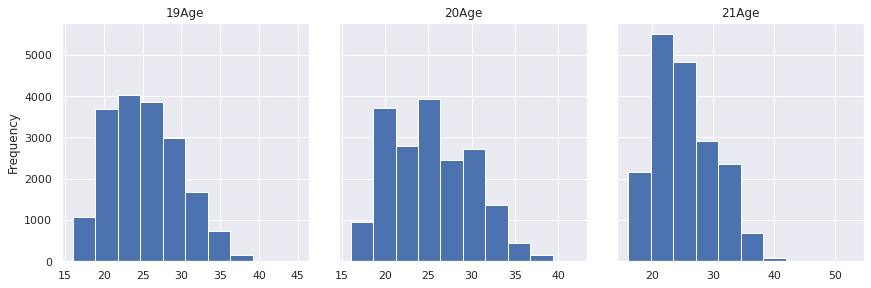

```python
fig, axes = plt.subplots(1,3,figsize = (12,4),sharey = True)
fig.tight_layout(h_pad =4)
sns.set(color_codes=True)
information19["19Age"].plot.hist(ax= axes[0]).set_title("19Age")
information20["20Age"].plot.hist(ax= axes[1]).set_title("20Age")
information21["21Age"].plot.hist(ax= axes[2]).set_title("21Age")
```

Next we also want to see whether the salaries of players have changed a lot under the influence of covid. We first normalized the salaries to ensure that the final chart display allows people to see the distribution of players' salaries at a glance.

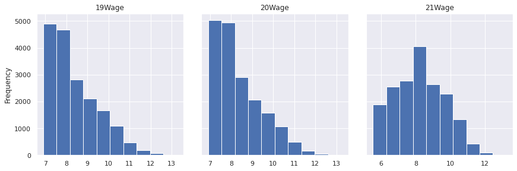

```python
fig, axes = plt.subplots(1,3,figsize = (12,4),sharey = True)
fig.tight_layout(h_pad =4)
sns.set(color_codes=True)
log19Wage = np.log(information19["19Wage"])
log20Wage = np.log(information20["20Wage"])
log21Wage = np.log(information21["21Wage"])
log19Wage.plot.hist(ax= axes[0]).set_title("19Wage")
log20Wage.plot.hist(ax= axes[1]).set_title("20Wage")
log21Wage.plot.hist(ax= axes[2]).set_title("21Wage")
```

Next, we want to analyze the changes in the value of players in the past three years. Whether the player's value has been reduced or increased by the impact of covid. At the same time, we also want to analyze the value distribution of players, trying to find out whether changes in player values are related to changes in other factors.

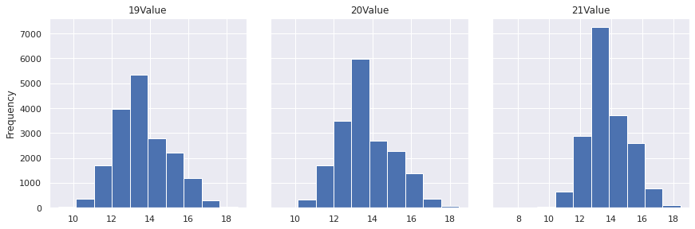

```python
fig, axes = plt.subplots(1,3,figsize = (12,4),sharey = True)
fig.tight_layout(h_pad =4)
sns.set(color_codes=True)
log19Value = np.log(information19["19Value"])
log20Value = np.log(information20["20Value"])
log21Value = np.log(information21["21Value"])
log19Value.plot.hist(ax = axes[0]).set_title("19Value")
log20Value.plot.hist(ax = axes[1]).set_title("20Value")
log21Value.plot.hist(ax = axes[2]).set_title("21Value")
```

We also speculate whether players from some countries will be worth more. Country is likely to be an important factor affecting player value changes.

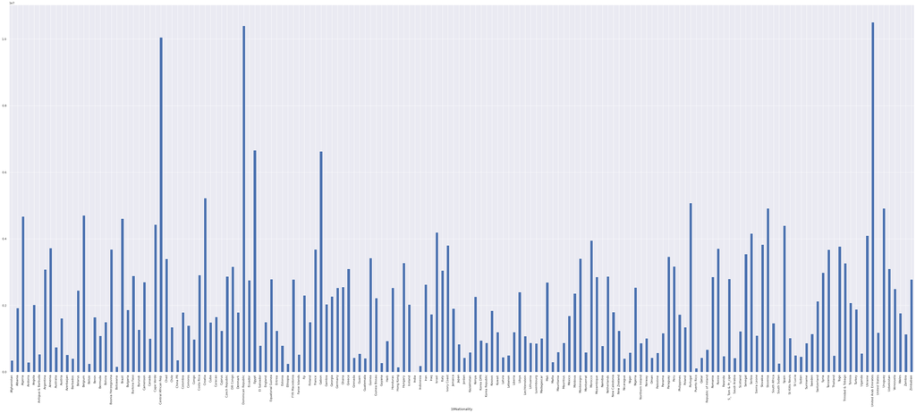

```python
information19.groupby(["19Nationality"])["19Value"].mean().plot.bar(figsize=(60,25))
```

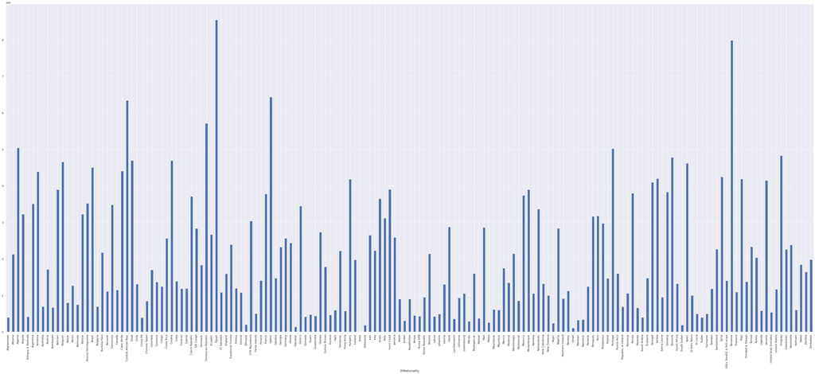

```python
information20.groupby(["20Nationality"])["20Value"].mean().plot.bar(figsize=(60,25))
```

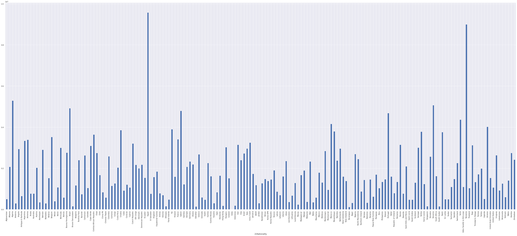

```python
information21.groupby(["21Nationality"])["21Value"].mean().plot.bar(figsize=(60,25))
```

# EDA

Next, we will try to find out the correlation between the player's value and his age and wage. We firstly think that there are some close connections between the player's value and his age and wage. We will use several graphs to prove and illustrate our ideas.

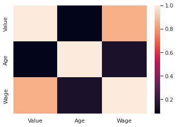

```python
features = ["Value","Age","Wage"]
corr = data19[features].corr()
corr
sns.heatmap(corr)
```

From the correlation graph, we can easily find out the results that the player's value has high correlation with the player's wage, but it has almost no connection to the player's age.

```python
# Save the change csv to the new csv which not include the string in the Value, Age, Wage
path1 = "/content/drive/MyDrive/CMPS3160_Project/data/19.csv"
data19 = pd.read_csv(path1, sep=",",encoding = "ISO-8859-1")

path2 = "/content/drive/MyDrive/CMPS3160_Project/data/20.csv"
data20 = pd.read_csv(path2, sep=",",encoding = "ISO-8859-1")

path3 = "/content/drive/MyDrive/CMPS3160_Project/data/21.csv"
data21 = pd.read_csv(path3, sep=",",encoding = "ISO-8859-1")
```

```python
import plotly.express as px
nat_cnt=data19.groupby('Nationality').apply(lambda x:x['Name'].count()).reset_index(name='Counts')
nat_cnt.sort_values(by='Counts',ascending=False,inplace=True)
top_20_nat_cnt=nat_cnt[:20]
fig=px.bar(top_20_nat_cnt,x='Nationality',y='Counts',color='Counts',title='Nationwise Representation in the FIFA Game')
fig.show()
```

[interactive chart not shown]

```python
import plotly.express as px
cost_prop=data21[['Name','Club','Nationality','Wage','Value','Position']]
fig=px.scatter(cost_prop,x='Value',y='Wage',color='Value',size='Wage',hover_data=['Name','Club','Nationality','Position'],title='Value vs Wage Presentation of all the Players')
fig.show()
```

[interactive chart not shown]

From the scatter graph above, we can see that the player who has higher wage will have the higher value in the FIFA, also the player who has lower wage will have the lower value in the FIFA. (The graph shows an linear interaction with stimated positive slope.)

After finding out the relationship between value and wage, we want to explore the relationships between the player's value and his position. We want to find out which position of the player has higher value than others? This provides us with a basis going forward. Let’s see how every position takes a bite out of the pie.

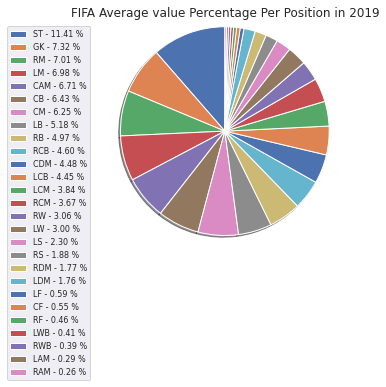

```python
y = data19.groupby("Position")[["Value"]].sum()
y = y.reset_index()
y.groupby("Position")[["Value"]].sum()
y.sort_values("Value",ascending=False,inplace=True)

mylabels = y["Position"]
ys = y["Value"]

percent = 100.*ys/ys.sum()
patches, texts = plt.pie(ys, startangle=90, radius=1.2,shadow = True)
labels = ['{0} - {1:1.2f} %'.format(i,j) for i,j in zip(mylabels,percent)]

sort_legend = True
if sort_legend:
    patches, labels, dummy =  zip(*sorted(zip(patches, labels, ys),
                                          key=lambda x: x[2],
                                          reverse=True))

plt.legend(patches, labels, loc='upper right', bbox_to_anchor=(-0.1, 1.),
           fontsize=8)
plt.title("FIFA Average value Percentage Per Position in 2019")

plt.show()
```

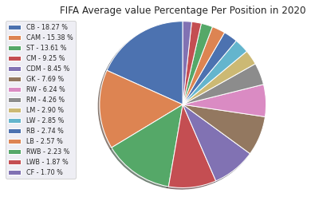

```python
y = data20.groupby("BP")[["Value"]].sum()
y = y.reset_index()
y.groupby("BP")[["Value"]].sum()
y.sort_values("Value",ascending=False,inplace=True)

mylabels = y["BP"]
ys = y["Value"]

percent = 100.*ys/ys.sum()
patches, texts = plt.pie(ys, startangle=90, radius=1.2,shadow = True)
labels = ['{0} - {1:1.2f} %'.format(i,j) for i,j in zip(mylabels,percent)]

sort_legend = True
if sort_legend:
    patches, labels, dummy =  zip(*sorted(zip(patches, labels, ys),
                                          key=lambda x: x[2],
                                          reverse=True))

plt.legend(patches, labels, loc='upper right', bbox_to_anchor=(-0.1, 1.),
           fontsize=8)
plt.title("FIFA Average value Percentage Per Position in 2020")

plt.show()
```

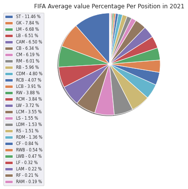

```python
y = data21.groupby("Position")[["Value"]].sum()
y = y.reset_index()
y.groupby("Position")[["Value"]].sum()
y.sort_values("Value",ascending=False,inplace=True)

mylabels = y["Position"]
ys = y["Value"]

percent = 100*ys/ys.sum()
patches, texts = plt.pie(ys, startangle=90, radius=1.2,shadow = True)
labels = ['{0} - {1:1.2f} %'.format(i,j) for i,j in zip(mylabels,percent)]

sort_legend = True
if sort_legend:
    patches, labels, dummy =  zip(*sorted(zip(patches, labels, ys),
                                          key=lambda x: x[2],
                                          reverse=True))

plt.legend(patches, labels, loc='upper right', bbox_to_anchor=(-0.1, 1.),
           fontsize=8)
plt.title("FIFA Average value Percentage Per Position in 2021")

plt.show()
```

```python
def mon_to_num(num):
    if type(num) == int:
        return num
    a = list(num)
    if a[0] == "€":
        a.remove("€")
    if a[-1] == "K":
        a.remove("K")
    if a[-1] == "M":
        a.remove("M")
        a = float("".join(a))
        a = int(a)
        a = str(a)+"000"
        a = list(a)
    b = int("".join(a))
    return b


del_list = list()
for i in range(0,len(data190["Wage"])):
    if type(data190["Wage"][i]) == str and list(data190["Wage"][i])[0] == "€" and list(data190["Wage"][i])[-1] == "K":
        data190["Wage"][i] = mon_to_num(data190["Wage"][i])
    elif type(data190["Wage"][i]) == str and list(data190["Wage"][i])[0] == "€" and list(data190["Wage"][i])[-1] == "M":
        data190["Wage"][i] = mon_to_num(data190["Wage"][i])
    else :
        del_list.append(i)

data190 = data190.drop(del_list)
data190.reset_index(inplace=True,drop=True)
data190 = data190.loc[data190["Age"].notnull()]
data190.reset_index(inplace=True,drop=True)
data19_final = data190.loc[:,["Age","Wage","Value"]]

del_list = list()
for i in range(0,len(data19_final["Value"])):
    if type(data19_final["Value"][i]) == str and list(data19_final["Value"][i])[0] == "€" and list(data19_final["Value"][i])[-1] == "K":
        data19_final["Value"][i] = mon_to_num(data19_final["Value"][i])
    elif type(data19_final["Value"][i]) == str and list(data19_final["Value"][i])[0] == "€" and list(data19_final["Value"][i])[-1] == "M":
        data19_final["Value"][i] = mon_to_num(data19_final["Value"][i])
    else :
        del_list.append(i)

data19_final = data19_final.drop(del_list)
data19_final.reset_index(inplace=True,drop=True)
data19_final
```

|  | Age | Wage | Value |
| --- | --- | --- | --- |
| 0 | 31 | 565 | 110000 |
| 1 | 33 | 405 | 77000 |
| 2 | 26 | 290 | 118000 |
| 3 | 27 | 260 | 72000 |
| 4 | 27 | 355 | 102000 |
| ... | ... | ... | ... |
| 17619 | 19 | 1 | 60 |
| 17620 | 19 | 1 | 60 |
| 17621 | 16 | 1 | 60 |
| 17622 | 17 | 1 | 60 |
| 17623 | 16 | 1 | 60 |

17624 rows × 3 columns

```python
def mon_to_num(num):
    if type(num) == int:
        return num
    a = list(num)
    if a[0] == "€":
        a.remove("€")
    if a[-1] == "K":
        a.remove("K")
    if a[-1] == "M":
        a.remove("M")
        a = float("".join(a))
        a = int(a)
        a = str(a)+"000"
        a = list(a)
    b = int("".join(a))
    return b

del_list = list()


for i in range(0,len(data_2["Wage"])):
    if type(data_2["Wage"][i]) == str and list(data_2["Wage"][i])[0] == "€" and list(data_2["Wage"][i])[-1] == "K":
        data_2["Wage"][i] = mon_to_num(data_2["Wage"][i])
    elif type(data_2["Wage"][i]) == str and list(data_2["Wage"][i])[0] == "€" and list(data_2["Wage"][i])[-1] == "M":
        data_2["Wage"][i] = mon_to_num(data_2["Wage"][i])
    else :
        del_list.append(i)

data_2 = data_2.drop(del_list)

data_2.reset_index(inplace=True,drop=True)

data_2 = data_2.loc[data_2["Age"].notnull()]

data_2_final = data_2.loc[:,["Age","Wage","Value"]]

del_list = list()
for i in range(0,len(data_2_final["Value"])):
    if type(data_2_final["Value"][i]) == str and list(data_2_final["Value"][i])[0] == "€" and list(data_2_final["Value"][i])[-1] == "K":
        data_2_final["Value"][i] = mon_to_num(data_2_final["Value"][i])
    elif type(data_2_final["Value"][i]) == str and list(data_2_final["Value"][i])[0] == "€" and list(data_2_final["Value"][i])[-1] == "M":
        data_2_final["Value"][i] = mon_to_num(data_2_final["Value"][i])
    else :
        del_list.append(i)

data_2_final = data_2_final.drop(del_list)

data_2_final.reset_index(inplace=True,drop=True)

data20_fianl = data_2_final
```

```python
data21.loc[data21["Wage"].isnull()]
data21.loc[data21["Value"].isnull()]
data21.loc[data21["Age"].isnull()]

data21_final = data21.loc[:,["Age","Wage","Value"]]
```

```python
dataf = pd.concat((data19_final,data20_final,data21_final),axis=0)
```

```python
label_need=dataf.keys()
print(label_need)
```

```
Index(['Age', 'Wage', 'Value'], dtype='object')
```

```python
#define x and y
x = dataf[label_need].values[:,0:2]
y = dataf[label_need].values[:,2]
print(x)
print(y)
```

```
[['31' 565]
 ['33' 405]
 ['26' 290]
 ...
 [35 0]
 [32 20000]
 [35 6000]]
[110000 77000 118000 ... 0 2200000 110000]
```

```python
from sklearn.model_selection import train_test_split
x_train, x_test, y_train, y_test = train_test_split(x, y, random_state=33, test_size=0.25)
#  print(x_test.shape)
# Train the model
from sklearn.neighbors import KNeighborsRegressor
k = 5
knn = KNeighborsRegressor(k)
knn.fit(x_train, y_train)
```

```
KNeighborsRegressor()
```

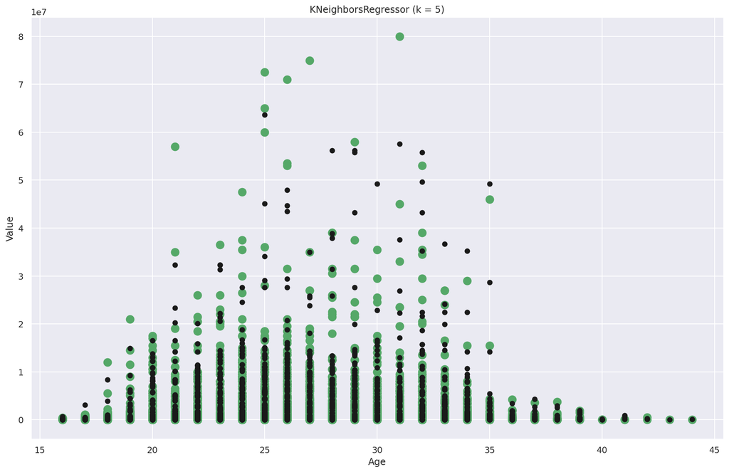

```python
y_pred = knn.predict(x_test)
plt.figure(figsize=(16, 10), dpi=144)
plt.scatter(x_test[:,0], y_test, c='g', s=100)
plt.scatter(x_test[:,0], y_pred, c='k')
plt.axis('tight')
plt.title("KNeighborsRegressor (k = %i)" % k)
plt.xlabel("Age")
plt.ylabel("Value")
plt.show()
```

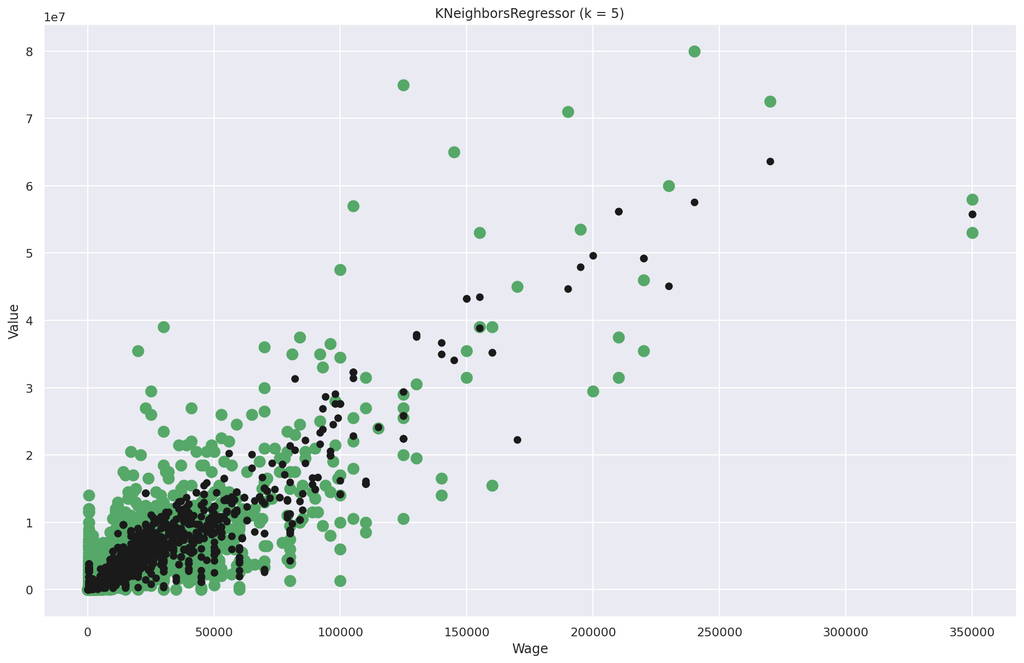

```python
plt.figure(figsize=(16, 10), dpi=144)
plt.scatter(x_test[:,1], y_test, c='g', s=100)
plt.scatter(x_test[:,1], y_pred, c='k')
plt.axis('tight')
plt.title("KNeighborsRegressor (k = %i)" % k)
plt.xlabel("Wage")
plt.ylabel("Value")
plt.show()
```

From the Knn regression graph above, We can predict the player's value based on his age and wage.

Nevertheless, while this project is far from perfect, we are satisfied with what we've created, and can proudly display a working analysis with many interesting aspects.

This is our final product for our FIFA Player Value Analysis, and thank you for reading.

# Cover Format

```python
%%shell
jupyter nbconvert --to html /content/drive/MyDrive/CMPS3160_Project/Project.ipynb
# Change our notebook format to the html format
```

```
[NbConvertApp] Converting notebook /content/drive/MyDrive/CMPS3160_Project/Project.ipynb to html
[NbConvertApp] Writing 2767513 bytes to /content/drive/MyDrive/CMPS3160_Project/Project.html
```

# Final Plan

We changed some of our previous code in the current project and added missing explanations. We currently spend a lot of time looking for the right data, and we find it very difficult to find very suitable data. In addition, we will continue to use the knowledge learned in class to continue research.